# Chapter 13: Some practical forecasting issues

maurogm 2023-08-29

- Link
- Weekly, daily and sub-daily data
  - Weekly data
- Método CROSTON para Count data de baja frecuencia
- Ensuring forecasts stay within limits
  - Positive forecasts
  - Forecasts constrained to an interval
- Forecast combinations
  - Forecasts puntuales
  - Forecast combination distributions
- Prediction intervals for aggregates
- Backcasting
- Forecasting on training and test sets
  - Multi-step forecasts on training data
  - One-step forecasts on test data
  - Outliers
  - Missing values

## Link

https://otexts.com/fpp3/practical.html

## Weekly, daily and sub-daily data

### Weekly data

Hay que usar modelos que puedan lidiar con una periodicidad no entera (52+1/7 semanas en el año), no todos los años tienen la misma cantidad de semanas:

```r
us_gasoline %>%
  group_by(year = year(Week)) %>%
  filter(Week == max(Week))
```

```
## # A tsibble: 27 x 3 [1W]
## # Groups:    year [27]
##        Week Barrels  year
##      <week>   <dbl> <dbl>
##  1 1991 W52    7.19  1991
##  2 1992 W53    7.36  1992
##  3 1993 W52    7.57  1993
##  4 1994 W52    7.72  1994
##  5 1995 W52    7.04  1995
##  6 1996 W52    7.74  1996
##  7 1997 W52    8.20  1997
##  8 1998 W53    8.52  1998
##  9 1999 W52    8.85  1999
## 10 2000 W52    8.69  2000
## # … with 17 more rows
```

Por ejemplo, un modelo de descomposición:

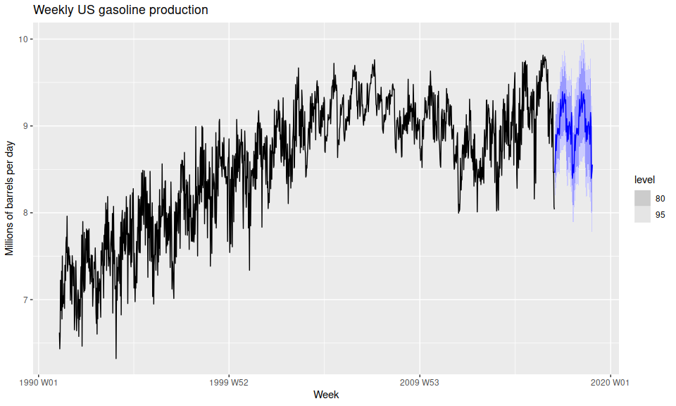

```r
my_dcmp_spec <- decomposition_model(
  STL(Barrels),
  ETS(season_adjust ~ season("N"))
)
us_gasoline |>
  model(stl_ets = my_dcmp_spec) |>
  forecast(h = "2 years") |>
  autoplot(us_gasoline) +
  labs(
    y = "Millions of barrels per day",
    title = "Weekly US gasoline production"
  )
```

O una regresión armónica:

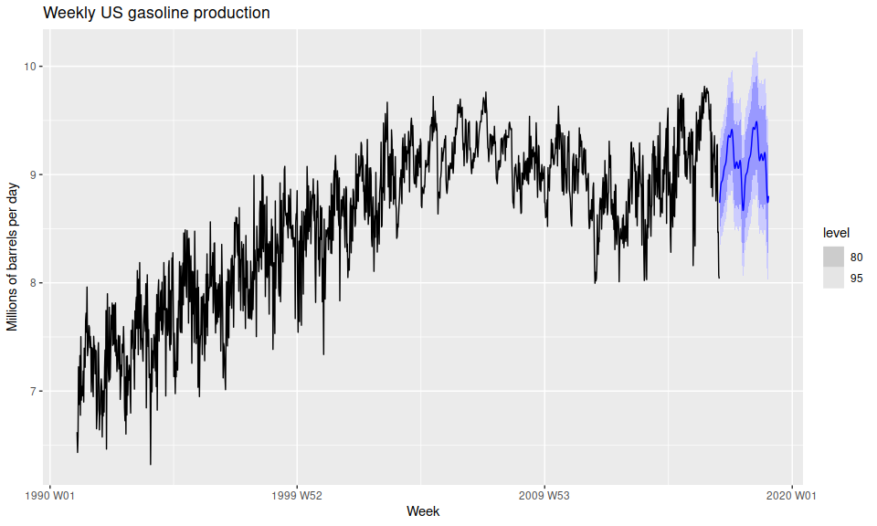

```r
gas_dhr <- us_gasoline |>
  model(dhr = ARIMA(Barrels ~ PDQ(0, 0, 0) + fourier(K = 6)))

gas_dhr |>
  forecast(h = "2 years") |>
  autoplot(us_gasoline) +
  labs(
    y = "Millions of barrels per day",
    title = "Weekly US gasoline production"
  )
```

## Método CROSTON para Count data de baja frecuencia

Es apropiado cuando tenemos series con muchos ceros, por ejemplo:

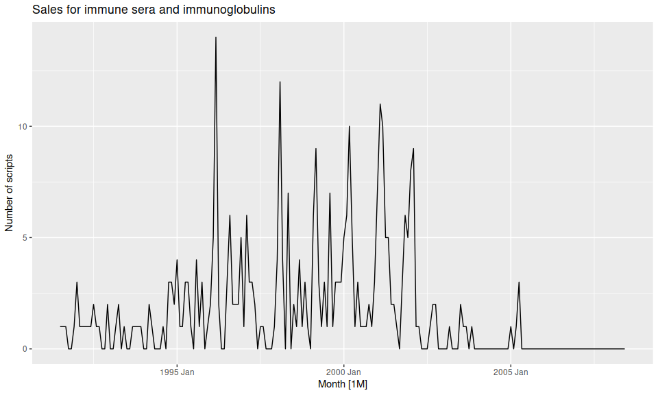

```r
j06 <- PBS |>
  filter(ATC2 == "J06") |>
  summarise(Scripts = sum(Scripts))

j06 |> autoplot(Scripts) +
  labs(
    y = "Number of scripts",
    title = "Sales for immune sera and immunoglobulins"
  )
```

El modelo `CROSTON` sólo da forecasts puntuales, y la predicción es constante en el tiempo:

```r
j06 |>
  model(CROSTON(Scripts)) |>
  forecast(h = 6)
```

```
## # A fable: 6 x 4 [1M]
## # Key:     .model [1]
##   .model              Month   Scripts .mean
##   <chr>               <mth>    <dist> <dbl>
## 1 CROSTON(Scripts) 2008 Jul 0.9735062 0.974
## 2 CROSTON(Scripts) 2008 Aug 0.9735062 0.974
## 3 CROSTON(Scripts) 2008 Sep 0.9735062 0.974
## 4 CROSTON(Scripts) 2008 Oct 0.9735062 0.974
## 5 CROSTON(Scripts) 2008 Nov 0.9735062 0.974
## 6 CROSTON(Scripts) 2008 Dec 0.9735062 0.974
```

## Ensuring forecasts stay within limits

### Positive forecasts

Lograr esto es fácil simplemente trabajando en la escala logarítmica:

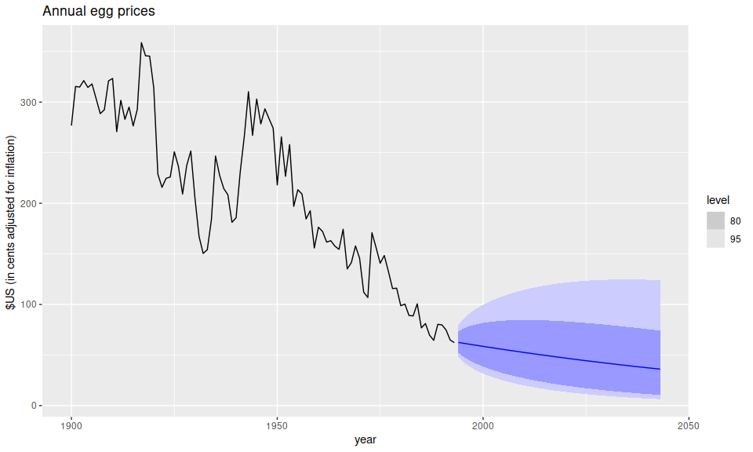

```r
egg_prices <- prices |> filter(!is.na(eggs))
log_model <- egg_prices |>
  model(ETS(log(eggs) ~ trend("A")))
log_model |>
  forecast(h = 50) |>
  autoplot(egg_prices) +
  labs(
    title = "Annual egg prices",
    y = "$US (in cents adjusted for inflation) "
  )
```

Chequeemos que los residuos parezcan ruido blanco:

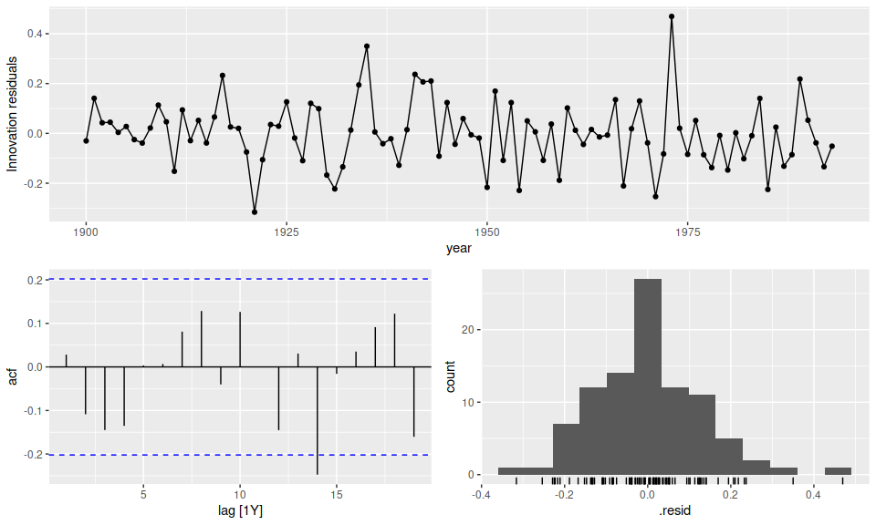

```r
log_model %>%
  gg_tsresiduals()
```

### Forecasts constrained to an interval

Si queremos que los forecasts estén entre a y b, usar una transformación logit sobre los datos antes de ajustar el modelo:

Volvamos al ejemplo anterior de los precios de los huevos, aunque sea poco realista. Notemos que esta no es una transformación estándar, pero `fabletools` nos permite crearla utilizando la función `new_transformation`, tras lo que podemos incluirla dentro de la fórmula del modelo:

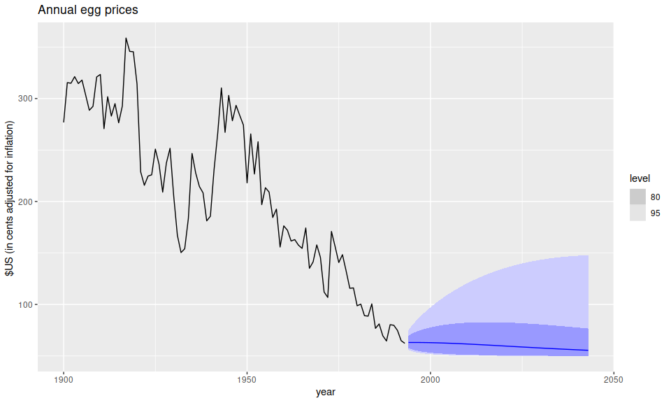

```r
scaled_logit <- function(x, lower = 0, upper = 1) {
  log((x - lower) / (upper - x))
}
inv_scaled_logit <- function(x, lower = 0, upper = 1) {
  (upper - lower) * exp(x) / (1 + exp(x)) + lower
}
my_scaled_logit <- new_transformation(
  scaled_logit, inv_scaled_logit
)
egg_prices |>
  model(
    ETS(my_scaled_logit(eggs, lower = 50, upper = 400)
    ~ trend("A"))
  ) |>
  forecast(h = 50) |>
  autoplot(egg_prices) +
  labs(
    title = "Annual egg prices",
    y = "$US (in cents adjusted for inflation) "
  )
```

## Forecast combinations

### Forecasts puntuales

Entrenando varios modelos y promediando las columnas del `mable` resultante con `mutate` podemos obtener un forecast combinado:

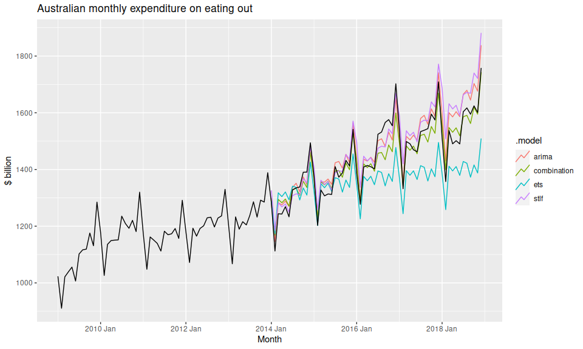

```r
auscafe <- aus_retail |>
  filter(stringr::str_detect(Industry, "Takeaway")) |>
  summarise(Turnover = sum(Turnover))
train <- auscafe |>
  filter(year(Month) <= 2013)
STLF <- decomposition_model(
  STL(log(Turnover) ~ season(window = Inf)),
  ETS(season_adjust ~ season("N"))
)
cafe_models <- train |>
  model(
    ets = ETS(Turnover),
    stlf = STLF,
    arima = ARIMA(log(Turnover))
  ) |>
  mutate(combination = (ets + stlf + arima) / 3)
cafe_fc <- cafe_models |>
  forecast(h = "5 years")

cafe_fc |>
  autoplot(auscafe |> filter(year(Month) > 2008),
    level = NULL
  ) +
  labs(
    y = "$ billion",
    title = "Australian monthly expenditure on eating out"
  )
```

El modelo combinado es mejor (en métricas puntuales) que los individuales:

```r
cafe_fc |>
  accuracy(auscafe) |>
  arrange(RMSE)
```

```
## # A tibble: 4 × 10
##   .model      .type     ME  RMSE   MAE    MPE  MAPE  MASE RMSSE  ACF1
##   <chr>       <chr>  <dbl> <dbl> <dbl>  <dbl> <dbl> <dbl> <dbl> <dbl>
## 1 combination Test    8.09  41.0  31.8  0.401  2.19 0.776 0.790 0.747
## 2 arima       Test  -25.4   46.2  38.9 -1.77   2.65 0.949 0.890 0.786
## 3 stlf        Test  -36.9   64.1  51.7 -2.55   3.54 1.26  1.23  0.775
## 4 ets         Test   86.5  122.  101.   5.51   6.66 2.46  2.35  0.880
```

### Forecast combination distributions

Si queremos ver el efecto en los forecasts predictivos, vemos que la combinación no calculó una distribución:

```
## $y
## [1] "$ billion"
##
## $title
## [1] "Australian monthly expenditure on eating out, with distribution of forecasts"
##
## attr(,"class")
## [1] "labels"
```

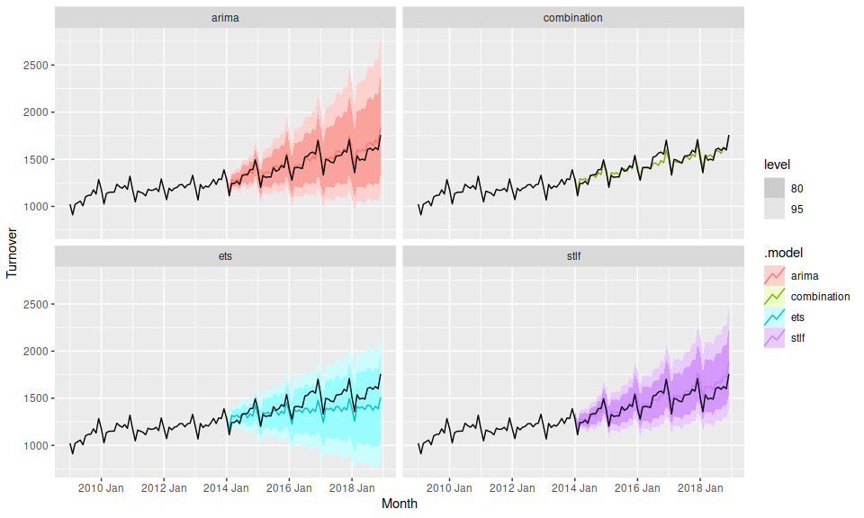

```r
cafe_fc |>
  autoplot(auscafe |> filter(year(Month) > 2008)) +
  facet_wrap(~.model, ncol = 2)
labs(
  y = "$ billion",
  title = "Australian monthly expenditure on eating out, with distribution of forecasts"
)
```

Esto es porque las distribuciones individuales provienen de familias distintas, y por ahora no está implementada su combinación:

```r
cafe_fc |> filter(Month == min(Month))
```

```
## # A fable: 4 x 4 [1M]
## # Key:     .model [4]
##   .model         Month           Turnover .mean
##   <chr>          <mth>             <dist> <dbl>
## 1 ets         2014 Jan      N(1289, 1118) 1289.
## 2 stlf        2014 Jan t(N(7.2, 0.00063)) 1326.
## 3 arima       2014 Jan t(N(7.2, 0.00061)) 1283.
## 4 combination 2014 Jan            1299.38 1299.
```

Para obtener una distribución combinada, podemos simular muestras de los modelos individuales y combinarlas. Nótese el uso de la función `distributional::dist_sample` para crear una columna de tipo `dist` que pueda ser reconocida por el `fable`:

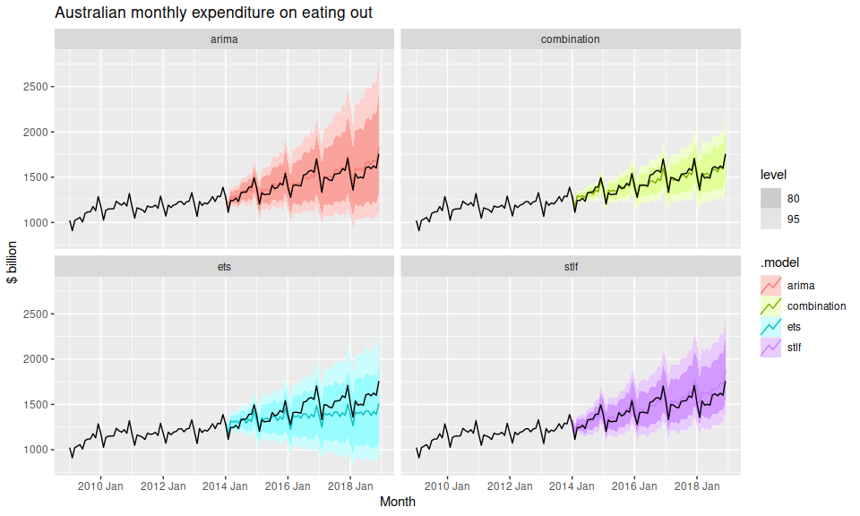

```r
cafe_futures <- cafe_models |>
  # Generate 1000 future sample paths
  generate(h = "5 years", times = 1000) |>
  # Compute forecast distributions from future sample paths
  as_tibble() |>
  group_by(Month, .model) |>
  summarise(
    dist = distributional::dist_sample(list(.sim))
  ) |>
  ungroup() |>
  # Create fable object
  as_fable(
    index = Month, key = .model,
    distribution = dist, response = "Turnover"
  )

cafe_futures |>
  autoplot(auscafe |> filter(year(Month) > 2008)) +
  facet_wrap(~.model, ncol = 2) +
  labs(
    y = "$ billion",
    title = "Australian monthly expenditure on eating out"
  )
```

Ahora sí contamos con una distribución combinada, que es de hecho más angosta que todas las demás.

Y al medir la performance, vemos que también en las métricas distribucionales la combinación tiene mejor score:

```r
cafe_futures |>
  accuracy(auscafe, list(crps = CRPS, winkler = winkler_score), level = 95) |>
  arrange(crps)
```

```
## # A tibble: 4 × 4
##   .model      .type  crps winkler
##   <chr>       <chr> <dbl>   <dbl>
## 1 combination Test   33.1    430.
## 2 stlf        Test   43.6    607.
## 3 arima       Test   49.5    792.
## 4 ets         Test   72.0    737.
```

## Prediction intervals for aggregates

Tal vez hacemos forecasts a nivel diario o mensual, pero nos interesa tener el forecast para todo el año. Lo que hacemos entonces es simular un montón de paths distintos, y luego sumarlos para obtener el forecast agregado.

Aquí es nuevamente práctico el uso de `distributional::dist_sample` para volver a crear un `dist` al que aplicarle métodos varios, como el cálculo de intervalos de confianza con `hilo`:

```r
fit <- auscafe |>
  # Fit a model to the data
  model(ETS(Turnover))
futures <- fit |>
  # Simulate 10000 future sample paths, each of length 12
  generate(times = 10000, h = 12) |>
  # Sum the results for each sample path
  as_tibble() |>
  group_by(.rep) |>
  summarise(.sim = sum(.sim)) |>
  # Store as a distribution
  summarise(total = distributional::dist_sample(list(.sim)))
futures |>
  mutate(
    mean = mean(total),
    pi80 = hilo(total, 80),
    pi95 = hilo(total, 95)
  )
```

```
## # A tibble: 1 × 4
##           total   mean                   pi80                   pi95
##          <dist>  <dbl>                 <hilo>                 <hilo>
## 1 sample[10000] 19207. [18318.82, 20119.97]80 [17864.13, 20625.91]95
```

## Backcasting

Si queremos “forecastear hacia atrás”, debemos invertir el índice temporal y usar alguno de los métodos habituales. Lo molesto es hacer los malabares para después volver a invertir el índice y que todo quede como queremos:

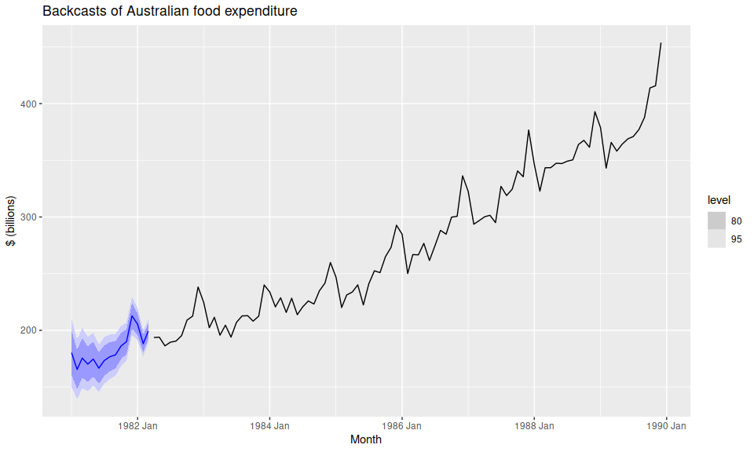

```r
backcasts <- auscafe |>
  mutate(reverse_time = rev(row_number())) |>
  update_tsibble(index = reverse_time) |>
  model(ets = ETS(Turnover ~ season(period = 12))) |>
  forecast(h = 15) |>
  mutate(Month = auscafe$Month[1] - (1:15)) |>
  as_fable(index = Month, response = "Turnover",
    distribution = "Turnover")
backcasts |>
  autoplot(auscafe |> filter(year(Month) < 1990)) +
  labs(title = "Backcasts of Australian food expenditure",
       y = "$ (billions)")
```

## Forecasting on training and test sets

```r
training <- auscafe |> filter(year(Month) <= 2013)
test <- auscafe |> filter(year(Month) > 2013)
cafe_fit <- training |>
  model(ARIMA(log(Turnover)))
```

### Multi-step forecasts on training data

Por defecto al extraer valores fitteados de un modelo se toman los fitted values a un paso:

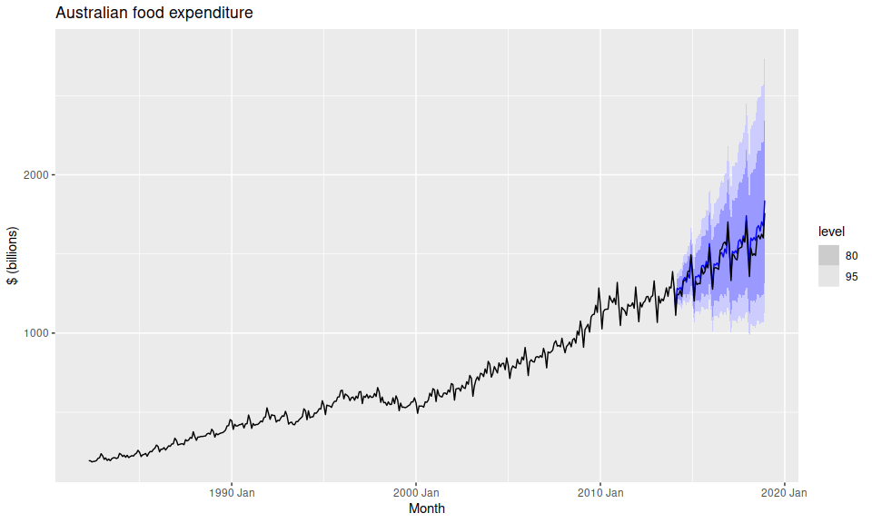

```r
cafe_fit |>
  forecast(h = 60) |>
  autoplot(auscafe) +
  labs(title = "Australian food expenditure",
       y = "$ (billions)")
```

Pero la función `fitted` permite especificar el parámetro `h` para obtener valores fitteados a más de un paso. Por ejemplo, con `h=12`:

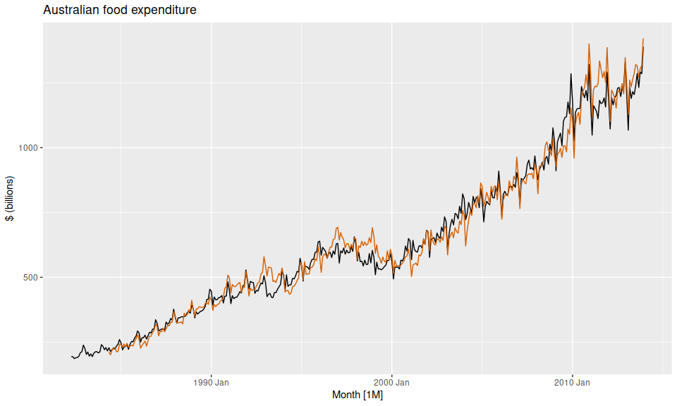

```r
fits12 <- fitted(cafe_fit, h = 12)
training |>
  autoplot(Turnover) +
  autolayer(fits12, .fitted, col = "#D55E00") +
  labs(title = "Australian food expenditure",
       y = "$ (billions)")
```

### One-step forecasts on test data

A veces dejamos un test set fuera, que queremos usar para evaluar el modelo. El problema es que a medida que nos alejamos del último dato conocido, la incertidumbre crece, dado que cada forecast se basa en el anterior. Esto es problemático en el caso de que queramos sumarizar los errores de los forecasts, dado que los mismos tendríąn distintas varianzas.

Lo que podemos hacer en este caso es usar los datos reales para generar cada nuevo forecast, de modo que todos los forecasts sean one-step. Nótese que no estamos re-entrenando el modelo: los parámetros son los calculados con los datos de entrenamiento. Lo que hacemos es usar los datos reales para generar los forecasts, de modo que la varianza se mantenga constante en todo el test set, y podamos sumarizarla con mayor facilidad.

La función `refit` permite hacer exactamente esto, tras lo que podemos usar `accuracy` para calcular las métricas (ignorar el hecho de que .type diga ‘Trainig’):

```r
cafe_fit |>
  refit(test) |>
  accuracy()
```

```
## # A tibble: 1 × 10
##   .model               .type     ME  RMSE   MAE    MPE  MAPE  MASE RMSSE    ACF1
##   <chr>                <chr>  <dbl> <dbl> <dbl>  <dbl> <dbl> <dbl> <dbl>   <dbl>
## 1 ARIMA(log(Turnover)) Train… -2.49  20.5  15.4 -0.169  1.06 0.236 0.259 -0.0502
```

## Dealing with outliers and missing values

### Outliers

Supongamos que tengamos una serie con un outlier, por ejemplo:

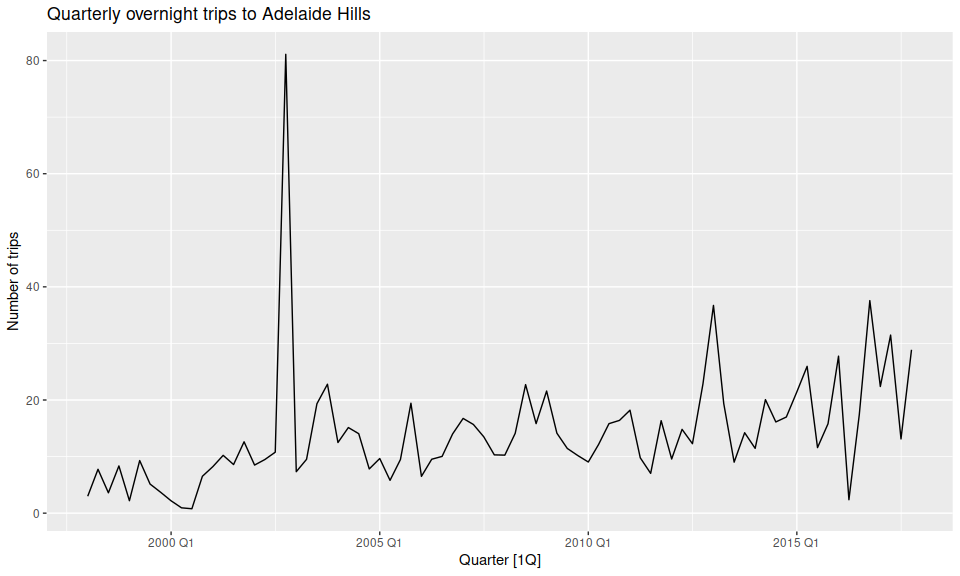

```r
tourism |>
  filter(
    Region == "Adelaide Hills", Purpose == "Visiting"
  ) |>
  autoplot(Trips) +
  labs(title = "Quarterly overnight trips to Adelaide Hills",
       y = "Number of trips")
```

Podemos usar `STL` con `robust = TRUE` para que el outlier no afecte la estimación de la tendencia:

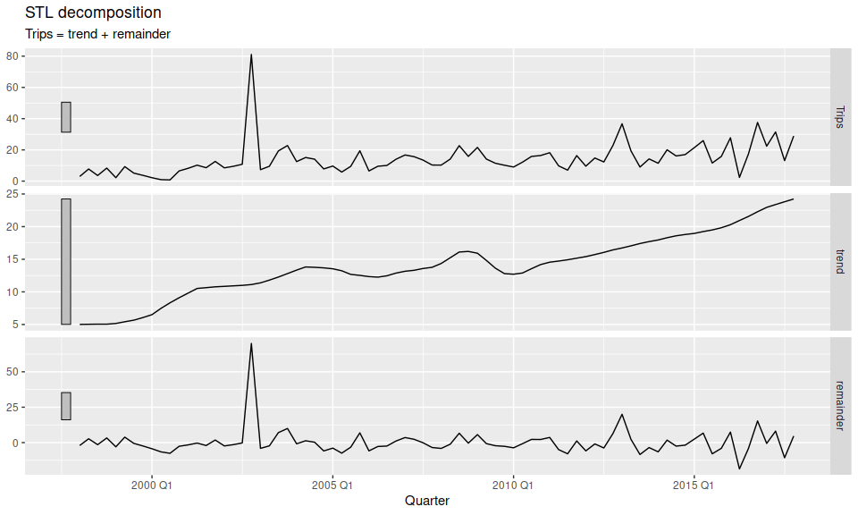

```r
ah_decomp <- tourism |>
  filter(
    Region == "Adelaide Hills", Purpose == "Visiting"
  ) |>
  # Fit a non-seasonal STL decomposition
  model(
    stl = STL(Trips ~ season(period = 1), robust = TRUE)
  ) |>
  components()
ah_decomp |> autoplot()
```

Una vez eliminado el efecto de la tendencia (y la estacionalidad, si la hubiera), podemos tratar de identificar los outliers en los residuos con los criterios tradicionales (ya sea como 1.5 veces el IQR o 3 veces el IQR):

```r
outliers <- ah_decomp |>
  filter(
    remainder < quantile(remainder, 0.25) - 3*IQR(remainder) |
    remainder > quantile(remainder, 0.75) + 3*IQR(remainder)
  )
outliers
```

```
## # A dable: 1 x 9 [1Q]
## # Key:     Region, State, Purpose, .model [1]
## # :        Trips = trend + remainder
##   Region        State Purpose .model Quarter Trips trend remainder season_adjust
##   <chr>         <chr> <chr>   <chr>    <qtr> <dbl> <dbl>     <dbl>         <dbl>
## 1 Adelaide Hil… Sout… Visiti… stl    2002 Q4  81.1  11.1      70.0          81.1
```

En este caso, el punto en cuestión es efectivamente identificado como outlier. Si decidimos eliminarlo, entonces surge el problema de qué hacer con el dato faltante.

### Missing values

Algunos modelos de `fable` pueden lidiar con datos faltantes, como NAIVE, ARIMA, dynamic regression models y NNAR.

Pero otros como STL y ETS no. Si quisiéramos usar uno de estos, podemos entrenar un modelo que admita datos faltantes y usarlo para estimar los puntos que nos falten. Por ejemplo, podemos usar un modelo ARIMA para estimar los valores faltantes en la serie de Adelaide Hills:

```r
ah_miss <- tourism |>
  filter(
    Region == "Adelaide Hills",
    Purpose == "Visiting"
  ) |>
  # Remove outlying observations
  anti_join(outliers) |>
  # Replace with missing values
  fill_gaps()
ah_fill <- ah_miss |>
  # Fit ARIMA model to the data containing missing values
  model(ARIMA(Trips)) |>
  # Estimate Trips for all periods
  interpolate(ah_miss)
```

La función `interpolate` toma un `mable` y devuelve un `tsibble` con los datos originales y los valores estimados para los períodos faltantes.

Efectivamente, comprobamos que `ah_fill` ahora contiene datos para el período del outlier:

```r
ah_fill |>
  # Only show outlying periods
  right_join(outliers |> select(-Trips))
```

```
## # A tsibble: 1 x 9 [?]
## # Key:       Region, State, Purpose [1]
##   Region        State Purpose Quarter Trips .model trend remainder season_adjust
##   <chr>         <chr> <chr>     <qtr> <dbl> <chr>  <dbl>     <dbl>         <dbl>
## 1 Adelaide Hil… Sout… Visiti… 2002 Q4  8.50 stl     11.1      70.0          81.1
```

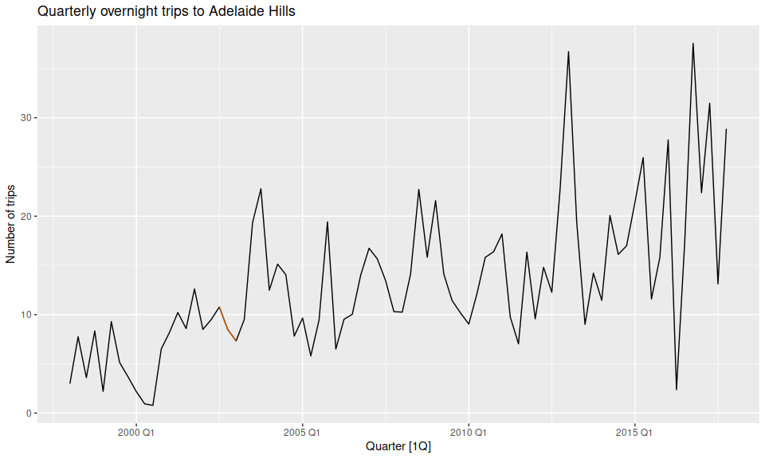

```r
ah_fill |>
  autoplot(Trips) +
  autolayer(ah_fill |> filter_index("2002 Q3"~"2003 Q1"),
    Trips, colour="#D55E00") +
  labs(title = "Quarterly overnight trips to Adelaide Hills",
       y = "Number of trips")
```

Ahora ya podemos usar algún modelo que no admita datos faltantes, como STL:

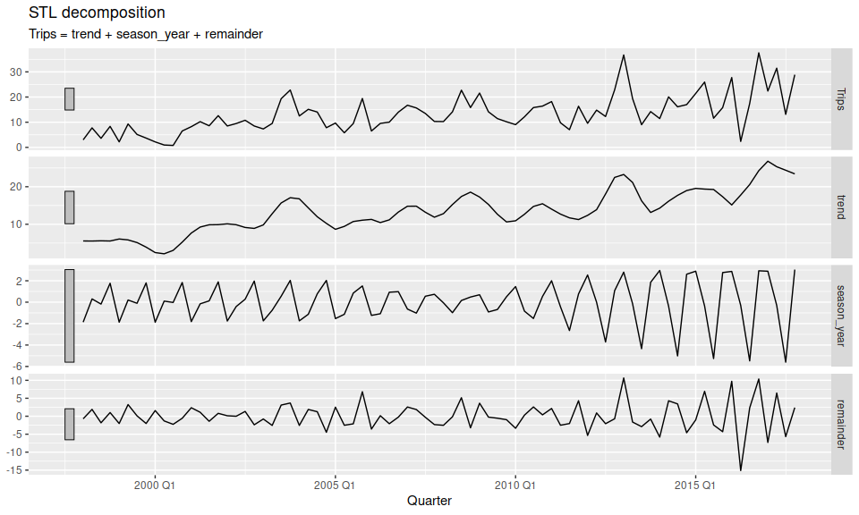

```r
ah_fill |>
  model(stl = STL(Trips)) |>
  components() |>
  autoplot()
```